# Predictive Modeling for Voter Turnout in the US Presidential Elections 2024

Sneha Mariam Thomas

#### **Introduction**

Accurately predicting voter turnout plays a crucial role in enhancing inclusive democratic representation. By identifying segments of the electorate who are less likely to participate in elections, we can effectively target outreach efforts. This targeted approach promotes broader civic engagement by addressing barriers that prevent certain groups from voting. In doing so, we strengthen the democratic process by ensuring that all voices are heard and represented in our electoral system. This proactive strategy not only encourages higher voter participation but also fosters a more inclusive and responsive democracy that reflects the diverse perspectives and interests of the population.

The project’s primary objective is to construct a predictive model for individual voter turnout in the upcoming November presidential election in the United States. Leveraging data from the Harvard Cooperative Congressional Election Study (CCES) for training, the model aims to accurately forecast whether voters will participate in the election. This predictive capability is crucial for targeting outreach efforts effectively towards individuals who are less likely to vote. By doing so, the project seeks to increase overall voter turnout, promote broader civic engagement, and ensure that election outcomes more faithfully represent the preferences of the entire electorate.

#### **Data Source**

The CCES dataset explores American perceptions of electoral accountability, voting behavior, and electoral experiences, investigating variations across political geography and social contexts. Administered online by YouGov, the 2022 CCES survey involved interviews with 60,000 adults between September and November 2022. This extensive dataset collects crucial pre-election data through a standardized questionnaire, ensuring contemporary insights essential for precise turnout predictions in 2024. Analyzing its comprehensive array of pre-election variables facilitates targeted outreach efforts aimed at potential non-voters.

For a comprehensive understanding of the survey questions and detailed dataset information, please consult the following [link](https://dataverse.harvard.edu/dataset.xhtml?persistentId=doi%3A10.7910/DVN/PR4L8P). Question *CC22_363* has been utilized as a proxy to gauge 2024 voting intention, drawing on responses obtained in 2022. Responses categorized as 1, 3, and 4 denote a strong commitment and have been classified as “Will Vote (0)”. Responses categorized as 2, 5, and 6, indicating uncertainty or disinterest, have been categorized as “No (1)”.

#### **Feature Engineering**

- **Feature Selection**: The model development process aimed to simplify variables while preserving predictive power. For example, detailed variables like specific church affiliations were removed to reduce complexity. Instead, broader indicators such as respondents’ religion were retained to capture essential aspects of religious identity affecting voter turnout. This approach resulted in 118 variables being retained for analysis, after evaluating and removing other variables based on their relevance and granularity.
- **Missing Values**: Addressing missing data challenges in this research, the implementation of the *Multiple Imputation by Chained Equations (MICE)* method was crucial. MICE utilizes a predictive mean matching algorithm to iteratively impute missing values, making it well-suited for datasets with non-random missingness and complex variable relationships. By leveraging observed data, MICE generates multiple imputations that preserve the integrity of the original data distribution. This approach was pivotal due to significant missing values in the dataset and the need to accurately capture variable interdependencies during imputation. MICE’s ability to simulate realistic values based on observed patterns ensured imputations aligned closely with the dataset’s structure. Methodologically, MICE’s iterative approach enabled systematic handling of missing data, maintaining statistical power and reducing bias in the analyses. Integration of multiple imputations enhanced the reliability and completeness of findings, thereby reinforcing the study’s validity.
- **Categorical Variable Encoding**: All variables except birth year were categorical and subsequently underwent one-hot encoding, while birth year was transformed into age.Transforming categorical columns through one-hot encoding captures categorical data as binary vectors, preserving their distinct values as individual features for analysis.

#### **Model Evaluation**

Metrics for model comparison are as follows:

Model Evaluation Metrics

| Metric | XGBoost | Ranger |
| --- | --- | --- |
| Recall | 0.77 | 0.583 |
| F1 Score | 0.73 | 0.689 |
| PR-AUC | 0.829 | 0.824 |
| Accuracy | 0.861 | 0.872 |
| Precision | 0.694 | 0.84 |
| Log Loss | 0.315 | 0.298 |

Positive Class-1 (Not Voting)

The primary objective is to accurately identify individuals unlikely to participate in voting, which is complicated by an imbalanced class distribution. To address this challenge, metrics such as recall, F1 score, and Precision-Recall Area Under the Curve (PR-AUC) are focused upon. Recall indicates the model’s ability to capture instances of the positive class while minimising false negatives. The F1 score, as the harmonic mean of precision and recall, is vital for assessing model performance in imbalanced datasets where high precision and recall are both essential and when comparing models with differing strengths in precision and recall. In datasets with rare positive classes, PR-AUC is more informative than ROC-AUC as it focuses on the precision-recall trade-off.

In prioritising the accurate identification of non-voters within an imbalanced dataset, XGBoost’s higher recall (0.77), F1 score (0.73) and PR-AUC compared to Ranger’s metrics position it as a potentially more effective choice.

#### **Features Selection**

In the context of budget constraints and dimensionality reduction, feature selection is imperative for maximising model efficacy. SHAP (SHapley Additive exPlanations) quantifies the contribution of each feature to model predictions and can be leveraged for feature selection by prioritising influential predictors based on their impact on model performance.

In the following SHAP plot, the y-axis displays top thirty features arranged by importance, with the mean SHAP value listed alongside:

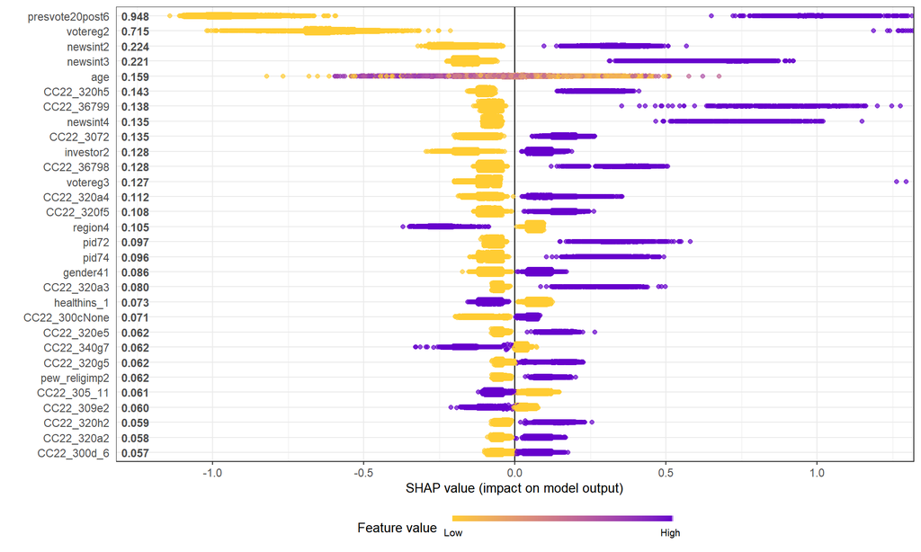

The report elaborates on selected features; for additional details, please refer to the CCES guidebook. After studying the questions and considering their SHAP values, seventeen features were shortlisted. This approach aimed at potentially reducing the dimensionality of the dataset while retaining the most significant drivers of model predictions.

The selected features encompass key themes critical for understanding political and social behavior, including voting behavior, political engagement, demographics, socioeconomic factors, personal beliefs, and immigration status. These features provide insights into electoral participation, levels of political involvement and sentiment, and the broader population’s characteristics. They also reveal the economic backgrounds influencing political views and highlight individual value systems and social orientations. Additionally, the inclusion of immigration status allows for examining the perspectives and behaviors of immigrant populations. This comprehensive framework enables a nuanced analysis of the diverse factors shaping political attitudes and actions. Following table enlists the selected features:

Selected Features and Description

| Features | Description |
| --- | --- |
| presvote20post | 2020 Presidential Election Voting Decision |
| votereg | Are you registered voter? |
| votereg_f | Is your current zip your voter registration address? |
| newsint | Do you keep up with politics and public affairs? |
| age | Age |
| CC22_320 | Approval of various political entities (e.g., Joe Biden, Congress). |
| investor | Do you invest in stocks? |
| pid3 | Which political party do you align with? |
| CC22_307 | How do police make you feel? |
| gender4 | Gender |
| region | Residential census region |
| pew_religimp | How important is religion to you? |
| healthins | Do you have health insurance? |
| educ | Highest level of education |
| immstat | Immigration status details |
| CC22_300d | Political activity on social media in the last day |
| CC22_36799 | Did not vote for U.S. House of Representatives |

#### **Final Model Performance**

The model,post tuning, was then re-trained on the selected features to optimise both resource allocation and model performance and following are its results:

Evaluation Metrics(XGBOOST with Feature Selection )

| Metric | Value |
| --- | --- |
| Recall | 0.8197058 |
| F1 Score | 0.7100311 |
| PR-AUC | 0.8239020 |
| Accuracy | 0.8369167 |
| Precision | 0.6262415 |
| Log Loss | 0.3556840 |

Positive Class-1 (Not Voting)

#### **Conclusion**

This study aimed to develop a predictive model for individual voter turnout in the upcoming November presidential election in the United States using machine learning techniques. Data from the Harvard Cooperative Congressional Election Study (CCES) was leveraged to identify segments of the electorate less likely to participate in elections, crucial for targeted outreach efforts to enhance voter turnout and ensure representative election outcomes.

Implications of this study extend beyond academic discourse, offering practical insights for policymakers and electoral strategists. By leveraging predictive analytics to discern patterns in voter behavior, targeted outreach efforts can be tailored to encourage broader civic engagement and ensure more inclusive democratic representation. This approach not only optimizes resource allocation but also promotes a more responsive electoral process that reflects diverse societal perspectives and priorities.

While this research leveraged sophisticated machine learning techniques to extract predictive insights, it acknowledges inherent limitations such as potential biases in survey data and the contextual specificity of electoral dynamics. Future endeavors should focus on refining models and expanding datasets to enhance the generalizability and robustness of predictive analytics in electoral forecasting.

#### **REFERENCE**

Schaffner, B., Ansolabehere, S., & Shih, M. (2023). Cooperative Election Study Common Content, 2022 (Version V4). Harvard Dataverse. https://doi.org/10.7910/DVN/PR4L8P

#### **APPENDIX**

##### **Appendix 1: Performance Metrics Results**

**1. XGBOOST**

```
## Confusion Matrix and Statistics
##
##           Reference
## Prediction    0    1
##          0 8086  673
##          1  991 2250
##
##                Accuracy : 0.8613
##                  95% CI : (0.855, 0.8675)
##     No Information Rate : 0.7564
##     P-Value [Acc > NIR] : < 2.2e-16
##
##                   Kappa : 0.6371
##
##  Mcnemar's Test P-Value : 7.781e-15
##
##             Sensitivity : 0.7698
##             Specificity : 0.8908
##          Pos Pred Value : 0.6942
##          Neg Pred Value : 0.9232
##              Prevalence : 0.2436
##          Detection Rate : 0.1875
##    Detection Prevalence : 0.2701
##       Balanced Accuracy : 0.8303
##
##        'Positive' Class : 1
##
```

**2. RANGER**

```
## Confusion Matrix and Statistics
##
##           Reference
## Prediction    0    1
##          0 8753 1218
##          1  324 1705
##
##                Accuracy : 0.8715
##                  95% CI : (0.8654, 0.8774)
##     No Information Rate : 0.7564
##     P-Value [Acc > NIR] : < 2.2e-16
##
##                   Kappa : 0.611
##
##  Mcnemar's Test P-Value : < 2.2e-16
##
##             Sensitivity : 0.5833
##             Specificity : 0.9643
##          Pos Pred Value : 0.8403
##          Neg Pred Value : 0.8778
##              Prevalence : 0.2436
##          Detection Rate : 0.1421
##    Detection Prevalence : 0.1691
##       Balanced Accuracy : 0.7738
##
##        'Positive' Class : 1
##
```

**3. XGBOOST with FEATURES SELECTION**

```
## Confusion Matrix and Statistics
##
##           Reference
## Prediction    0    1
##          0 7647  527
##          1 1430 2396
##
##                Accuracy : 0.8369
##                  95% CI : (0.8302, 0.8435)
##     No Information Rate : 0.7564
##     P-Value [Acc > NIR] : < 2.2e-16
##
##                   Kappa : 0.5994
##
##  Mcnemar's Test P-Value : < 2.2e-16
##
##             Sensitivity : 0.8197
##             Specificity : 0.8425
##          Pos Pred Value : 0.6262
##          Neg Pred Value : 0.9355
##              Prevalence : 0.2436
##          Detection Rate : 0.1997
##    Detection Prevalence : 0.3188
##       Balanced Accuracy : 0.8311
##
##        'Positive' Class : 1
##
```

#### **Appendix 2: XGBOOST MODEL SPECIFICATIONS**

Hyperparameter tuning specifications after features were selected:

```r
xgb_best_params <- list(
  objective = "binary:logistic",
  eval_metric = "auc",
  eta = 0.01,
  max_depth = 3,
  min_child_weight = 4,
  gamma = 0,
  subsample = 0.5,
  colsample_bytree = 0.4,
  reg_alpha = 1e-5,
  reg_lambda=0.01,
  nthread = 6,
  scale_pos_weight = ratio)
```

#### **Appendix 3: Code**

```r
# this chunk generates the complete code appendix.
# eval=FALSE tells R not to run (``evaluate'') the code here (it was already run before).
knitr::opts_chunk$set(echo = FALSE, warning = FALSE, message = FALSE, cache = TRUE, fig.align="center")
#Loading Libraries
library(ranger)
library(caret)
library(pROC)
library(ranger)
library(doParallel)
library(mlr)
library(tuneRanger)
library(xgboost)
library(caTools)
library(dplyr)
library(cvms)
library(caret)
library(tidyverse)
library(Metrics)
library(MLmetrics)
library(gridExtra)
library(knitr)
library(ggplot2)
library(kableExtra)
require(doMC)
library(htmltools)
library(SHAPforxgboost)
library(data.table)
library(here)

data <- read.csv("C:/Users/sneha/OneDrive/Desktop/Applied ML/Assessments/Summative 2/data/CCES22_Common_OUTPUT_vv_topost.csv")
copy_data <- data
output <- data$CC22_363
#Pre election dataset
df <- data[, 1:332]
del_columns <- c("X","commonpostweight","vvweight","vvweight_post","caseid","tookpost", "CCEStake", "add_confirm", "inputzip", "gender4_t", "race_other", "multrace_1", "multrace_2", "multrace_3", "multrace_4", "multrace_5", "multrace_8", "multrace_97", "multrace_98", "comptype", "regzip", "pid3_t", "ccesmodule", "CC22_309a_1", "CC22_309a_2", "CC22_309a_3", "CC22_309a_4", "CC22_309a_5", "CC22_306", "CC22_309b_1", "CC22_309b_2", "CC22_309b_3", "CC22_309b_4", "CC22_309d_t", "CC22_310a", "CC22_310b", "CC22_310c", "CC22_310d", "CC22_311a", "CC22_311b", "CC22_311c", "CC22_311d", "cit1", "CC22_321_1", "CC22_321_2", "CC22_321_3", "CC22_321_4", "CC22_321_5", "CC22_321_6", "CC22_321_7", "CC22_321_8", "CC22_327a", "CC22_327b", "CC22_327c", "CC22_327d", "CC22_330a", "CC22_330b", "CC22_330c", "CC22_330d", "CC22_330e", "CC22_330f", "CC22_331a", "CC22_331b", "CC22_331c", "CC22_331d", "CC22_332a", "CC22_332b", "CC22_332c", "CC22_332d", "CC22_332e", "CC22_332f", "C22_333a", "C22_333b", "C22_333c", "C22_333d", "C22_333e", "C22_334a", "C22_334b", "C22_334c", "C22_334d", "C22_334e", "C22_334f", "C22_334g", "C22_334h", "CC22_340c", "CC22_340d", "CC22_340e", "CC22_340f", "CC22_340h", "CC22_340i", "CC22_340j", "CC22_340k", "CC22_340l", "CC22_340m", "CC22_340n", "urbancity_t", "CC22_363", "CC22_365_voted", "CC22_365_voted_t", "CC22_365b_voted", "CC22_365b_voted_t", "CC22_366_voted", "CC22_366_voted_t", "CC22_367_voted", "CC22_367_voted_t", "CC22_365", "CC22_365_t", "CC22_365a", "CC22_365a_t", "CC22_365b", "CC22_365b_t", "CC22_365c", "CC22_365c_t", "CC22_366", "CC22_367_t", "CC22_367a", "CC22_367a_t", "employ_t", "pew_churatd", "pew_prayer", "religpew_t", "religpew_protestant", "religpew_protestant_t", "religpew_baptist", "religpew_baptist_t", "religpew_methodist_t", "religpew_nondenom", "religpew_nondenom_t", "religpew_lutheran", "religpew_lutheran_t", "religpew_presby", "religpew_presby_t", "religpew_pentecost", "religpew_pentecost_t", "religpew_episcop", "religpew_episcop_t", "religpew_christian", "religpew_christian_t", "religpew_congreg", "religpew_congreg_t", "religpew_holiness", "religpew_holiness_t", "religpew_reformed", "religpew_reformed_t", "religpew_advent", "religpew_advent_t", "religpew_catholic", "religpew_catholic_t", "religpew_mormon", "religpew_mormon_t", "religpew_orthodox", "religpew_orthodox_t", "religpew_jewish", "religpew_jewish_t", "religpew_muslim", "religpew_muslim_t", "religpew_buddhist", "religpew_buddhist_t", "religpew_hindu", "religpew_hindu_t", "dualctry", "ownhome_t", "healthins2", "phone", "internethome", "internetwork", "CC22_hisp_t","CC22_asian_t","presvote16post", "presvote16post_t", "industry", "child18num", "CC22_350a", "CC22_350a", "CC22_350b", "CC22_350c", "CC22_350d", "CC22_350e", "CC22_350f", "CC22_350g", "CC22_350h", "CC22_355a", "CC22_355b", "CC22_355c", "CC22_355d", "CC22_355e", "religpew_methodist", "CC22_hisp_1", "CC22_hisp_2", "CC22_hisp_3", "CC22_hisp_4", "CC22_hisp_5", "CC22_hisp_6", "CC22_hisp_7", "CC22_hisp_8", "CC22_hisp_9", "CC22_hisp_10", "CC22_hisp_11", "CC22_hisp_12", "CC22_asian_1", "CC22_asian_2", "CC22_asian_3", "CC22_asian_4", "CC22_asian_5", "CC22_asian_6", "CC22_asian_7", "CC22_asian_8", "CC22_asian_9", "CC22_asian_10", "CC22_asian_11", "CC22_asian_12", "CC22_asian_13", "CC22_asian_14", "CC22_asian_15")
df <- df[, !names(df) %in% del_columns]
df <- df[, -grep("CC22_300b", names(df))]
df <- df[, -grep("CC22_360", names(df))]
df <- df[, -grep("hadjob", names(df))]


#Removing columns where people could input text in 'Other' option
col_remove_text <- grep(".*_t", names(df))
# Remove columns
df <- df[, !(names(df) %in% names(df)[col_remove_text])]
df_final <- df

#Putting None for people who werent presented question and putting it as new columns
df_final$CC22_300a[df_final$CC22_300_2 != 1 & is.na(df_final$CC22_300a)] <- "None"
df_final$CC22_300c[df_final$CC22_300_3 != 1 & is.na(df_final$CC22_300c)] <- "None"
df_final$CC22_300d_7[df_final$CC22_300_1 == 2 & is.na(df_final$CC22_300d_1) & is.na(df_final$CC22_300d_2) & is.na(df_final$CC22_300d_3) & is.na(df_final$CC22_300d_4) & is.na(df_final$CC22_300d_5) & is.na(df_final$CC22_300d_6)] <- 1
df_final$CC22_300d_7[is.na(df_final$CC22_300d_7)] <- 2

# From year of birth to age
names(df_final)[names(df_final) == "birthyr"] <- "age"
df_final$age <- 2022 - df_final$age

#Factorise
df_final[,3:121] <- lapply(df_final[,3:121], factor)
dfs<- as.data.frame(df_final)

#Since state column has many inputs removed
df_nostate <- dfs[,-grep("inputstate", names(dfs))]

#Output and Weight
df_ot_wt <- copy_data[, c("CC22_363", "commonweight")]

# CHanging outputs to vote or not vote-> Factor
df_ot_wt$CC22_363[df_ot_wt$CC22_363 == 1 | df_ot_wt$CC22_363 == 3 | df_ot_wt$CC22_363 == 4] <- 0
df_ot_wt$CC22_363[df_ot_wt$CC22_363 == 2 | df_ot_wt$CC22_363 == 5 | df_ot_wt$CC22_363 == 6 | is.na(df_ot_wt$CC22_363)] <- 1
df_ot_wt$CC22_363 <- as.factor(df_ot_wt$CC22_363)

#COmprises the outfut as factor and all dataset except states name
main_data <- cbind(df_nostate, df_ot_wt$CC22_363)
#Ensuring column name matches
colnames(main_data)[colnames(main_data) == "df_ot_wt$CC22_363"] <- "CC22_363"
```

```r
#Split to Train and Test
set.seed(123)
train_index <- sort(sample(1: nrow(main_data), floor(0.8*nrow(main_data))))
datas <- list(train_data  = main_data[train_index,],
             test_data  = main_data[-train_index,],
             target_name = "CC22_363")

### SOURCE FOR FOLLOWING FUNCTIONS OF MICE: https://rmisstastic.netlify.app/how-to/external/how_to_predict_in_r
#NOTE: Given time to run code took 4hrs+, the resulst were stored as .csv file for subsequent use and faster knitting of R Markdown

#imputation_fun_mice <- function(df){
  #init <- mice(df, maxit=0, remove.collinear = FALSE, remove.constant = FALSE)
  #meth <- init$method
  #predM <- init$predictorMatrix
  #imputed <- mice(df, method=meth, predictorMatrix=predM, m=5, nnet.MaxNWts = 5000, remove.collinear = FALSE, remove.constant = FALSE, maxit = 1)
  #completed <- mice::complete(imputed)
  #return(completed)
#}

#get_imputed_data <- function(data, imputed_function){
  #train <- datas$train_data[, -c(which(colnames(datas$train_data) ==datas$target_name))]
  #test <- datas$test_data[, -c(which(colnames(datas$test_data) ==datas$target_name))]
  #expr_time <- system.time({
    #imputed_data <- lapply(list(train, test), imputed_function)
  #})

  #names(imputed_data) <- c('train_data', 'test_data')
  #imputed_data$train_data <- cbind(imputed_data$train_data, datas$train_data[, datas$target_name] )
  #imputed_data$test_data <- cbind(imputed_data$test_data, datas$test_data[, datas$target_name] )

  #colnames(imputed_data$train_data)[ncol(imputed_data$train_data ] <- datas$target_name
  #colnames(imputed_data$test_data)[ncol(imputed_data$test_data)] <- datas$target_name

  #return(list(imputed_data = imputed_data,
              #target_name = datas$target_name,
              #time = expr_time))}

#imputed_results_mice <- get_imputed_data(datas, imputation_fun_mice)

#Saving the results
#write.csv(imputed_results_mice$imputed_data$train_data, "train_mice.csv")
#write.csv(imputed_results_mice$imputed_data$test_data, "test_mice.csv")

imputed_train <- read.csv("C:/Users/sneha/OneDrive/Desktop/Applied ML/Assessments/Summative 2/data/train_mice.csv")[,-1]
imputed_test <- read.csv("C:/Users/sneha/OneDrive/Desktop/Applied ML/Assessments/Summative 2/data/test_mice.csv")[,-1]

imputed_train[,3:121] <- as.data.frame(lapply(imputed_train[,3:121], as.factor))
imputed_test[,3:121] <- as.data.frame(lapply(imputed_test[,3:121], as.factor))

#One Hot Encoding: TRAIN
#Some variables are already hot encoded
dummy <- imputed_train[,grep("(\\w+_\\d{1,2}$)|(CC22_363)",names(imputed_train))]
train_ne <- imputed_train[, !(names(imputed_train) %in% names(dummy))]
#Adding states as they also have to be hot encoded
train_ne <- cbind(train_ne, dfs$inputstate[train_index])
#Hot encoding to all except weight
train_encoded <- as.data.frame(model.matrix(~ . - 1, data = train_ne))

# Converting
# Change columns into numeric, except the target column
dummy[,1:54] <- as.data.frame(lapply(dummy[,1:54], as.numeric))
dummy[,1:54][dummy[,1:54] == 2] <- 0
# Change back to factor
dummy[,1:54] <- as.data.frame(lapply(dummy[,1:54], as.factor))
train_final <- cbind(train_encoded, dummy)
train_final[,3:ncol(train_final)] <- lapply(train_final[,3:ncol(train_final)], factor)
#Cleaning column names of states encoded
state_col <- colnames(train_final)[237:286]
state_number <- gsub("`dfs\\$inputstate\\[train_index\\]`", "", state_col)
new_state_names <- paste0("inputstate_", state_number)
colnames(train_final)[237:286] <- new_state_names

#ONE HOT ENCODING: TEST
test_dummy <- imputed_test[, grep("(\\w+_\\d{1,2}$)|(CC22_363)", names(imputed_test))]
test_ne <- imputed_test[, !(names(imputed_test) %in% names(test_dummy))]
#COlumn in train data baut not test
test_ne$CC22_3677 <- 0
test_ne <- cbind(test_ne,dfs$inputstate[-train_index])
test_encoded <- as.data.frame(model.matrix(~ . - 1, data = test_ne))
test_dummy[,1:54] <- as.data.frame(lapply(test_dummy[,1:54], as.numeric))
test_dummy[,1:54][test_dummy[,1:54] == 2] <- 0
# Change back to factor
test_dummy[,1:54] <- as.data.frame(lapply(test_dummy[,1:54], as.factor))
test_final <- cbind(test_encoded, test_dummy)
test_final[,3:ncol(test_final)] <- lapply(test_final[,3:ncol(test_final)], factor)
state_names <- colnames(test_final)[237:286]
state_col <- gsub("`dfs\\$inputstate\\[-train_index\\]`", "", state_names)
new_state_names <- paste0("inputstate_", state_col)
colnames(test_final)[237:286] <- new_state_names

#XGBOOST
column_index_to_exclude <- which(colnames(train_final) == "CC22_363")
train_x <- train_final[,-column_index_to_exclude]
train_y <- train_final$CC22_363
train_y <- as.numeric(as.character(train_y))
train_weights <- train_final$commonweight
train_x <- train_x[,-1]
train_x[, -1] <- lapply(train_x[, -1], function(x) as.numeric(as.character(x)))


col_to_exclude <- which(colnames(test_final) == "CC22_363")
test_x <- test_final[,-col_to_exclude]
test_y <- test_final$CC22_363
test_y <- as.numeric(as.character(test_y))
test_weights <- test_final$commonweight
test_x <- test_x[,-1]
test_x[, -1] <- lapply(test_x[, -1], function(x) as.numeric(as.character(x)))

#XGBOOST
ratio <- sum(train_y == 0)/sum(train_y == 1)

train_matrix <- model.matrix(~., data = train_x)
test_x_add <- as.numeric(as.character(test_x$CC22_3677))
test_x_add_matrix <- matrix(test_x_add, ncol = 1)
test_x <- test_x[, -which(names(test_x) == "CC22_3677")]
test_matrix <- model.matrix(~., data = test_x)
test_matrix <- cbind(test_matrix, test_x_add_matrix)
colnames(test_matrix)[340] <- "CC22_3677"

# Subset test_matrix to reorder its columns based on train_matrix's column order
column_order <- colnames(train_matrix)
test_matrix_reordered <- test_matrix[, column_order]

#Removing intercept from matrix creation
train_matrix <- train_matrix[,-1]
test_matrix_reordered <- test_matrix_reordered[,-1]


xgb_train <- xgb.DMatrix(data = train_matrix, label = train_y, weight = train_weights)
xgb_test <- xgb.DMatrix(data = test_matrix_reordered, label = test_y )

### HYPER PARAMTER TUNING DONE IN PYTHON DUE TO CRASH ISSUES IN R
###_____________________________________________________________________
#SOURCE: https://www.analyticsvidhya.com/blog/2016/03/complete-guide-parameter-tuning-xgboost-with-codes-python/
#Function Used to tune:
#from xgboost import XGBClassifier
#from sklearn import metrics
#import matplotlib.pyplot as plt
```

```r
#target= 'x'

#def modelfit(alg, dtrain, predictors, weights=None, useTrainCV=True, cv_folds=5, early_stopping_rounds=50):

  #if useTrainCV:
  #xgb_param = alg.get_xgb_params()
  #xgtrain = xgb.DMatrix(dtrain[predictors].values, label=dtrain[target].values, weight=weights)
  #cvresult = xgb.cv(xgb_param, xgtrain, num_boost_round=alg.get_params()['n_estimators'], nfold=cv_folds,
                  #metrics='auc', early_stopping_rounds=early_stopping_rounds)
  #alg.set_params(n_estimators=cvresult.shape[0])
  #best_iteration_index = cvresult['test-auc-mean'].idxmax()

  # Print CV results
  #print("CV Results:")
  #print(cvresult)
  #print("\nBest Iteration: ", best_iteration_index)

  # Fit the algorithm on the data
  #alg.fit(dtrain[predictors], dtrain[target], sample_weight=weights, eval_metric='auc')

  # Predict training set
  #dtrain_predictions = alg.predict(dtrain[predictors])
  #dtrain_predprob = alg.predict_proba(dtrain[predictors])[:,1]

  # Print model report
  #print ("\nModel Report")
  #print ("Accuracy : %.4g" % metrics.accuracy_score(dtrain[target].values, dtrain_predictions))
  #print ("AUC Score (Train): %f" % metrics.roc_auc_score(dtrain[target], dtrain_predprob))

  #feat_imp = pd.Series(alg.feature_importances_, index=predictors).sort_values(ascending=False)
  #feat_imp.plot(kind='bar', title='Feature Importances')
  #plt.ylabel('Feature Importance Score')

#train = pd.concat([train_x, train_y], axis=1)
#train = pd.concat([train, train_weights], axis=1)
#predictors = train_x.columns.tolist()
#________________________________________________________________________________

#Based on above hyperparamter tuning following values were determined:

#Given the time taken to run the following code and susbequent lag in knitting file,
#following code has been commented:

xgb_params <- list(
  objective = "binary:logistic",
  eval_metric = "auc",
  eta = 0.01,
  max_depth = 4,
  min_child_weight = 3,
  gamma = 0.1,
  subsample = 0.7,
  colsample_bytree = 0.8,
  reg_alpha = 6,
  nthread = 6,
  scale_pos_weight = ratio)

#Training XGB MODEL AND SAVING IT FOR FURTHER USE
#xgb_model <- xgb.train(
 #params = xgb_params,
 #data = xgb_train,
 #verbose = 1,
 #nrounds = 5000,
 #set.seed(123))
#xgb.save(xgb_model, 'xgb_final.model')

xgb_model <- xgb.load("C:/Users/sneha/OneDrive/Desktop/Applied ML/Assessments/Assignment/xgb_final.model")
result <- predict(xgb_model, xgb_test)

xgb_pred <- ifelse(result>0.5,1,0)
conf_mat_xg<- confusionMatrix(as.factor(xgb_pred),as.factor(test_y), positive = "1")
accuracy_xg <- (conf_mat_xg$overall["Accuracy"])
precision_xg <- (conf_mat_xg$byClass["Pos Pred Value"])
recall_xg <- (conf_mat_xg$byClass["Sensitivity"])
f1_score_xg <- (2*precision_xg*recall_xg)/sum(precision_xg,recall_xg)
logloss_xg <- logLoss(as.numeric(test_y), as.numeric(result))
pr_auc_xg <- PRAUC(result,test_y)


#AREA UNDER CURVE
#roc_xg <- roc(as.factor(test_y), result)
#auc_xg <- auc(roc_xg)
#par(pty="s")
#plot(roc_xg, col = "blue", lwd = 2, main = "ROC Curve:XGBOOST",legacy.axes= TRUE,print.auc=TRUE)

metric_names_xg <- c( "Recall", "F1 Score","PR-AUC","Accuracy", "Precision","Log Loss")
metric_values_xg <- c(recall_xg, f1_score_xg,pr_auc_xg, accuracy_xg, precision_xg,logloss_xg)
metrics_df_xg  <- data.frame(Metric = metric_names_xg ,Value = metric_values_xg )
rownames(metrics_df_xg ) <- NULL



#RANGER

ra_trainx <- as.data.frame(train_matrix)
ra_testx <- as.data.frame(test_matrix_reordered)
ra_weights <- train_weights
ra_testy <- as.numeric(as.character(test_y))
ra_trainy <- as.numeric(as.character(train_y))

#For class imbalance
class_0 <-  sum(ra_trainy == 0)
class_1 <- sum(ra_trainy==1)
ra_tot <- nrow(ra_trainx)
weight0 <- ra_tot/(2*class_0)
weight1 <- ra_tot/(2*class_1)

ra_train <- cbind(as.factor(ra_trainy),ra_trainx)
colnames(ra_train)[1] <- "vote_int"
ra_test <- cbind(as.factor(ra_testy),ra_testx)
colnames(ra_test)[1] <- "vote_int"

#HYPERPARAMETER TUNING: RANGER
# Create training and testing tasks
#library(mlr)
#train_task <- makeClassifTask(data = ra_train, target = "vote_int", weights = ra_weights)
#test_task <- makeClassifTask(data = ra_test, target = "vote_int")

# Create a ranger learner
#ranger <- makeLearner("classif.ranger", predict.type = "prob", fix.factors.prediction = TRUE, par.vals = list(num.trees = 1000, importance = "permutation", replace = FALSE, scale.permutation.importance = TRUE, respect.unordered.factors='order', mtry = 18, sample.fraction = 0.5))

# Set the parameters for ranger
#rfparam_ranger <- makeParamSet(
  #makeIntegerParam("num.trees", lower = 100, upper = 0.01*nrow(ra_train)),
  #makeIntegerParam("mtry", lower = 18, upper = 0.4 *(ncol(ra_train)-1)),
  #makeDiscreteParam("sample.fraction", values = c(0.5, 0.65, 0.7,0.75,0.8)),
  #makeDiscreteParam("importance", values = c("permutation", "impurity")),
  #makeDiscreteParam("respect.unordered.factors", values = c("order", "ignore"))
#)

# Set the control parameters
#ctrl_ra <- makeTuneControlRandom(maxit = 10L)

# Set the cross-validation  parameters
#set_cv_ra <- makeResampleDesc("CV", iters = 3L)

#Parallelize the process
#doParallel::registerDoParallel()

# Tune the ranger parameters
#ra_tune <- tuneParams(learner = ranger, task = train_task, resampling = set_cv_ra, par.set = rfparam_ranger, control = ctrl_ra, measures = list(auc, mmce))

#Based on parameters selected

#doParallel::registerDoParallel()
#ranger_model <- ranger::ranger(vote_int ~ ., data = ra_train, num.trees = 1000,
                               #importance = "permutation", replace = FALSE, scale.permutation.importance = TRUE,
                               #respect.unordered.factors='ignore', mtry = 40, sample.fraction = 0.7,
                               #seed = 123, num.threads = 6, write.forest = TRUE,
                               #probability = TRUE, case.weights = ra_weights,
                               #class.weights = c("0" =weight0, "1" = weight1))

ranger_model <- readRDS("C:/Users/sneha/OneDrive/Desktop/Applied ML/Assessments/Assignment/ranger_model.rds")
ranger_pred <- predict(ranger_model, data = ra_test, type = "response")
```

```r
ranger_prob_mat <- ranger_pred$predictions
ranger_prob_class1 <- ranger_prob_mat[, "1"]
ranger_pred <- ifelse(ranger_prob_mat[, "1"] > 0.5, 1, 0)

#Confusion Matrix
conf_mat_ranger <- confusionMatrix(as.factor(ranger_pred), as.factor(ra_testy),positive="1")
accuracy_ranger <- (conf_mat_ranger$overall["Accuracy"])
precision_ranger <- (conf_mat_ranger$byClass["Pos Pred Value"])
recall_ranger <- (conf_mat_ranger$byClass["Sensitivity"])
f1_score_ranger <- (2*precision_ranger*recall_ranger)/sum(precision_ranger,recall_ranger)
log_loss_ranger <- logLoss(as.numeric(ra_testy), ranger_prob_class1)
pr_auc_ranger <- PRAUC(ranger_prob_class1,ra_testy)


metric_names_ranger <- c( "Recall", "F1 Score","PR-AUC","Accuracy", "Precision","Log Loss")
metric_values_ranger <- c(recall_ranger, f1_score_ranger,pr_auc_ranger, accuracy_ranger, precision_ranger,log_loss_ranger)
metrics_df_ranger  <- data.frame(Metric = metric_names_ranger ,Value = metric_values_ranger )
rownames(metrics_df_ranger ) <- NULL

comparison_df <- cbind( metric_names_ranger,round(metrics_df_xg[, 2],3), round(metrics_df_ranger[, 2],3))
colnames(comparison_df) <- c("Metric", "XGBoost", "Ranger")
comparison_tables <- kable(comparison_df, align = "c", format = "html",
                          caption = "Model Evaluation Metrics") %>%add_footnote("Positive Class-1 (Not Voting)",notation="none") %>% kable_styling(full_width = 100)%>%column_spec(c(1:3), border_left = TRUE, border_right = TRUE)

comparison_tables
shap_values <- shap.values(xgb_model = xgb_model, X_train = xgb_train)
shap_long <- shap.prep(xgb_model = xgb_model, shap_contrib = shap_values$shap_score, X_train = train_matrix, top_n = 30)
shap_plot <- shap.plot.summary(shap_long, x_bound  = 1.2, dilute = 10)
shap_plot
variables <- c("presvote20post", "votereg", "votereg_f", "newsint", "age",
               "CC22_320", "investor", "pid3", "CC22_307", "gender4",
               "region", "pew_religimp", "healthins", "educ", "immstat", "CC22_300d","CC22_36799")

descriptions <- c("2020 Presidential Election Voting Decision",
                  "Are you registered voter?",
                  "Is your current zip your voter registration address?",
                  "Do you keep up with politics and public affairs?",
                  "Age",
                  "Approval of various political entities (e.g., Joe Biden, Congress).",
                  "Do you invest in stocks?",
                  "Which political party do you align with?",
                  "How do police make you feel?",
                  "Gender",
                  "Residential census region",
                  "How important is religion to you?",
                  "Do you have health insurance?",
                  "Highest level of education",
                  "Immigration status details",
                  "Political activity on social media in the last day",
                  "Did not vote for U.S. House of Representatives")

# Create a data frame
selected_variables <- data.frame(Features = variables, Description = descriptions)

feat_sel <- kable(selected_variables, align = "c", format = "html",
     caption = "Selected Features and Description") %>%
  kable_styling(full_width = FALSE) %>%
  column_spec(c(1, 2), border_left = TRUE, border_right = TRUE)
feat_sel

# EXTRACTING FEATURES
tf_colnames <- c("presvote20post", "votereg", "newsint", "age$", "CC22_320", "CC22_36799", "investor", "pid3", "CC22_307", "gender4", "region", "pew_religimp", "healthins", "educ", "votereg_f", "immstat", "CC22_300d")

tf_train <- ra_trainx[, grep(paste(tf_colnames, collapse="|"), names(ra_trainx))]
tf_test <- ra_testx[, names(tf_train)]

xgb_top_train <- xgb.DMatrix(data = as.matrix(tf_train), label = ra_trainy)
xgb_top_test <- xgb.DMatrix(data = as.matrix(tf_test), label = ra_testy)

#write.csv(tf_train,"tf_train.csv")
#write.csv(tf_test,"tf_test.csv")

xgb_best_params <- list(
  objective = "binary:logistic",
  eval_metric = "auc",
  eta = 0.01,
  max_depth = 3,
  min_child_weight = 4,
  gamma = 0,
  subsample = 0.5,
  colsample_bytree = 0.4,
  reg_alpha = 1e-5,
  reg_lambda=0.01,
  nthread = 6,
  scale_pos_weight = ratio)

#Saving the XGB Model
#xgb_best_model <-xgb.train(
  #params = xgb_best_params,
  #data = xgb_top_train,
  #verbose = 1,
  #nrounds = 5000,
  #set.seed(123))

#xgb.save(xgb_best_model, 'xgb_topf.model')


xgb_b_model <- xgb.load("C:/Users/sneha/OneDrive/Desktop/Applied ML/Assessments/Assignment/xgb_topf.model")

tf_result <- predict(xgb_b_model, xgb_top_test)
xgb_pred_tf <- ifelse(tf_result>0.5,1,0)
b_tf <- confusionMatrix(as.factor(xgb_pred_tf),as.factor(ra_testy), positive = "1")
accuracy_tf <- (b_tf$overall["Accuracy"])
precision_tf <- (b_tf$byClass["Pos Pred Value"])
recall_tf <- (b_tf$byClass["Sensitivity"])
f1_score_tf <- (2*precision_tf*recall_tf)/sum(precision_tf,recall_tf)
log_loss_tf <- logLoss(as.numeric(test_y), as.numeric(tf_result))
pr_auc_tf <- PRAUC(tf_result,test_y)


#Evaluation Metrics: Visualisation
metric_names <- c("Recall", "F1 Score","PR-AUC","Accuracy", "Precision", "Log Loss")
metric_values <- c(recall_tf,f1_score_tf,pr_auc_tf,accuracy_tf,precision_tf,log_loss_tf)
metrics_df <- data.frame(Metric = metric_names,
                         Value = metric_values)
rownames(metrics_df) <- NULL

tf_table <- kable(metrics_df, format = "html",
                  caption = "Evaluation Metrics(XGBOOST with Feature Selection )") %>%
  kable_styling(full_width = FALSE,
                latex_options = "striped",
                bootstrap_options = c("striped", "hover", "condensed", "responsive"), # Bootstrap styling options
                font_size = 14) %>%
  add_footnote("Positive Class-1 (Not Voting)",notation="none") %>%
  column_spec(c(1:2), border_left = TRUE, border_right = TRUE)
tf_table
conf_mat_xg
conf_mat_ranger

b_tf
xgb_best_params <- list(
  objective = "binary:logistic",
  eval_metric = "auc",
  eta = 0.01,
  max_depth = 3,
  min_child_weight = 4,
  gamma = 0,
  subsample = 0.5,
  colsample_bytree = 0.4,
  reg_alpha = 1e-5,
  reg_lambda=0.01,
  nthread = 6,
  scale_pos_weight = ratio)
```

```r
# this chunk generates the complete code appendix.
# eval=FALSE tells R not to run (``evaluate'') the code here (it was already run before).
```